# Basic Simulations

Tan Ho

2022-10-16

```r
library(ffsimulator)
library(ggplot2)
```

ffsimulator runs simulations on a given fantasy league based that league’s rosters, scoring settings, and current redraft rankings, connecting this data to historical weekly performances for each (preseason) positional ranking.

This vignette will introduce the basic usage of ffsimulator - you may also be interested in the motivations and custom simulations vignettes!

## Usage - Simulating Seasons

ffsimulator connects directly to your league (via the [ffscrapr package](https://ffscrapr.ffverse.com)) and can be used at a high level with just a few lines of code:

```r
foureight_conn <- mfl_connect(2021, 22627)

foureight_sim <- ff_simulate(conn = foureight_conn, n_seasons = 10, n_weeks = 14)
foureight_sim
```

```
#> <ff_simulation: 10 simulated seasons of Four-Eight Dynasty League>
#> List of 7
#>  $ summary_simulation: tibble [12 × 11] (S3: tbl_df/tbl/data.frame)
#>  $ summary_season    : tibble [120 × 12] (S3: tbl_df/tbl/data.frame)
#>  $ summary_week      : tibble [1,680 × 16] (S3: tbl_df/tbl/data.frame)
#>  $ roster_scores     :Classes 'data.table' and 'data.frame': 51450 obs. of  23 variables:
#>  $ projected_scores  :Classes 'data.table' and 'data.frame': 51450 obs. of  14 variables:
#>  $ league_info       : tibble [1 × 17] (S3: tbl_df/tbl/data.frame)
#>  $ simulation_params : tibble [1 × 9] (S3: tbl_df/tbl/data.frame)
```

ffsimulator includes a few automatic plots that can be run on this ff_simulation object to get a quick sense of the simulation output:

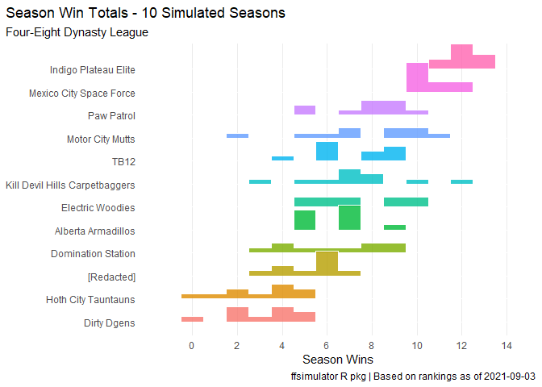

```r
plot(foureight_sim) # defaults to type = "wins"
```

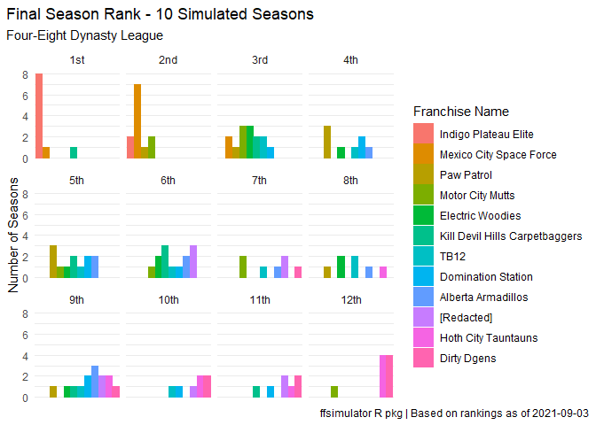

```r
plot(foureight_sim, type = "rank")
```

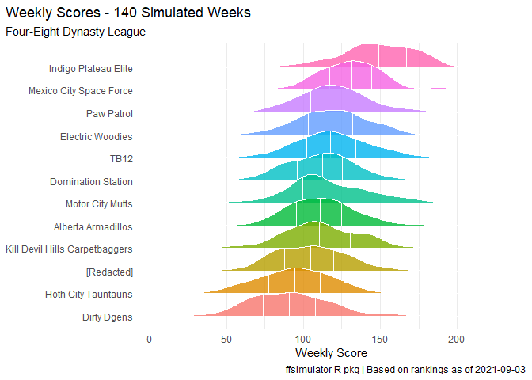

```r
plot(foureight_sim, type = "points")
```

You can also access the various component dataframes by name, for further analysis.

The `summary_simulation` table is a team-level summary across all of the simulated seasons.

```r
foureight_sim$summary_simulation
```

```
#> # A tibble: 12 × 11
#>    league_id franchise…¹ franc…² seasons h2h_w…³ h2h_w…⁴ allpl…⁵ allpl…⁶ point…⁷
#>    <chr>     <chr>       <chr>     <int>   <dbl>   <dbl>   <dbl>   <dbl>   <dbl>
#>  1 22627     0012        Indigo…      10    12.1   0.864   134.    0.867   2074.
#>  2 22627     0001        Mexico…      10    10.6   0.757   110     0.714   1842.
#>  3 22627     0007        Paw Pa…      10     7.8   0.557    84.9   0.551   1671.
#>  4 22627     0004        Electr…      10     7.4   0.529    84.2   0.547   1649.
#>  5 22627     0011        TB12         10     7.1   0.507    83.5   0.542   1659.
#>  6 22627     0005        Motor …      10     7.6   0.543    79.2   0.514   1626.
#>  7 22627     0009        Kill D…      10     7.3   0.521    74.8   0.486   1570.
#>  8 22627     0008        Domina…      10     6.3   0.45     73.6   0.478   1571.
#>  9 22627     0003        Albert…      10     6.4   0.457    71.4   0.464   1568.
#> 10 22627     0010        [Redac…      10     5.3   0.379    54.9   0.357   1458.
#> 11 22627     0006        Hoth C…      10     3     0.214    38.3   0.249   1318.
#> 12 22627     0002        Dirty …      10     3.1   0.221    35.7   0.232   1277.
#> # … with 2 more variables: points_against <dbl>, potential_points <dbl>, and
#> #   abbreviated variable names ¹franchise_id, ²franchise_name, ³h2h_wins,
#> #   ⁴h2h_winpct, ⁵allplay_wins, ⁶allplay_winpct, ⁷points_for
#> # ℹ Use `colnames()` to see all variable names
```

The `summary_season` table is a season-level summary of all weeks within those seasons - any one of these seasons “could” theoretically be the outcome of the upcoming season!

```r
foureight_sim$summary_season
```

```
#>      season league_id franchise_id                 franchise_name h2h_wins
#>   1:      1     22627         0001        Mexico City Space Force       12
#>   2:      1     22627         0002                    Dirty Dgens        0
#>   3:      1     22627         0003             Alberta Armadillos        5
#>   4:      1     22627         0004               Electric Woodies        7
#>   5:      1     22627         0005               Motor City Mutts       10
#>  ---
#> 116:     10     22627         0008             Domination Station        5
#> 117:     10     22627         0009 Kill Devil Hills Carpetbaggers       12
#> 118:     10     22627         0010                     [Redacted]        7
#> 119:     10     22627         0011                           TB12        8
#> 120:     10     22627         0012           Indigo Plateau Elite       11
#>      h2h_winpct allplay_wins allplay_games allplay_winpct points_for
#>   1:      0.857          125           154          0.812   2034.086
#>   2:      0.000           27           154          0.175   1187.849
```

[output cut: 21 more lines]

The `summary_week` table is a week-level summary of each team’s performance, including the optimal lineup that could have been played by the team and the randomly-generated lineup efficiency factor:

```r
foureight_sim$summary_week
```

```
#>       season season_week                 franchise_name optimal_score
#>    1:      1           1        Mexico City Space Force        166.65
#>    2:      1           1                    Dirty Dgens        145.65
#>    3:      1           1             Alberta Armadillos        108.13
#>    4:      1           1               Electric Woodies        166.51
#>    5:      1           1               Motor City Mutts        148.63
#>   ---
#> 1676:     10          14             Domination Station        182.70
#> 1677:     10          14 Kill Devil Hills Carpetbaggers        175.64
#> 1678:     10          14                     [Redacted]        134.50
#> 1679:     10          14                           TB12         64.17
#> 1680:     10          14           Indigo Plateau Elite        205.99
#>       lineup_efficiency team_score opponent_score result
#>    1:             0.691    115.169         76.084      W
#>    2:             0.737    107.286        132.011      L
```

[output cut: 45 more lines]

The `roster_scores` and `projected_scores` tables both provide individual player-week level scores, with the difference being that the `roster_scores` table is attached to franchise rosters (and thus duplicates rows if there are multiple copies of players within the league).

```r
foureight_sim$roster_scores
```

```
#>        fantasypros_id franchise_id franchise_name player_id   player_name pos
#>     1:          10007         0007     Paw Patrol     10413 Taylor, Tyrod  QB
#>     2:          10007         0007     Paw Patrol     10413 Taylor, Tyrod  QB
#>     3:          10007         0007     Paw Patrol     10413 Taylor, Tyrod  QB
#>     4:          10007         0007     Paw Patrol     10413 Taylor, Tyrod  QB
#>     5:          10007         0007     Paw Patrol     10413 Taylor, Tyrod  QB
#>    ---
#> 51446:           9907         0007     Paw Patrol     10313  Dalton, Andy  QB
#> 51447:           9907         0007     Paw Patrol     10313  Dalton, Andy  QB
#> 51448:           9907         0007     Paw Patrol     10313  Dalton, Andy  QB
#> 51449:           9907         0007     Paw Patrol     10313  Dalton, Andy  QB
#> 51450:           9907         0007     Paw Patrol     10313  Dalton, Andy  QB
#>        team  age salary contract_years roster_status draft_year draft_round
#>     1:  HOU 32.1   0.61              1        ROSTER       2011           6
#>     2:  HOU 32.1   0.61              1        ROSTER       2011           6
```

[output cut: 33 more lines]

Finally, some basic parameters are included, including `league_info` which is generated by `ffscrapr::ff_league()`.

```r
foureight_sim$league_info
```

```
#> # A tibble: 1 × 17
#>   league_id leagu…¹ season leagu…² franc…³ qb_type idp   scori…⁴ best_…⁵ salar…⁶
#>   <chr>     <chr>    <int> <chr>     <dbl> <chr>   <lgl> <chr>   <lgl>   <lgl>
#> 1 22627     Four-E…   2021 dynasty      12 2QB/SF  TRUE  0.5_pp… FALSE   TRUE
#> # … with 7 more variables: player_copies <dbl>, years_active <chr>,
#> #   qb_count <chr>, roster_size <dbl>, league_depth <dbl>, draft_type <chr>,
#> #   draft_player_pool <chr>, and abbreviated variable names ¹league_name,
#> #   ²league_type, ³franchise_count, ⁴scoring_flags, ⁵best_ball, ⁶salary_cap
#> # ℹ Use `colnames()` to see all variable names
```